# Ames Housing Dataset Regression Diagnostics

Jennifer Flora Bastian

2026-02-21

## Introduction

Housing prices depend on a combination of a home structure, size, and overall quality. Understanding how these factors influence sale prices is important not only for homeowners and real estate professionals, but also for typical home buyers who want to know what features add the most value before making a purchase. The Ames Housing dataset provides a detailed, real-world example of residential properties, making it well suited for regression analysis. This report aims to develop, interpret, and assess multiple linear regression models for predicting home sale prices. The analysis starts with exploratory data analysis and descriptive statistics to get a solid grasp of what’s in the dataset. Then I move on to data preparation and correlation analysis to identify the most important predictors. Scatter plots and regression models are then employed to explore the relationships between continuous variables and SalePrice.

Diagnostic methods are applied to evaluate essential regression assumptions, including linearity, normality, constant variance, multicollinearity, and the presence of outliers. When issues are detected, appropriate transformations are applied to enhance model performance. Finally, an all- subsets regression approach is used to identify the optimal model, which is then compared with a transformed model to determine which yields superior results.

## Load Libraries

```r
#Load Libraries
library(dplyr)
```

```r
library(ggplot2)
library(scales)
library(corrplot)
library(RColorBrewer)
library(car)
library(leaps)
```

## Load the Dataset

```r
#Import the dataset
housing_dataset <- read.csv("AmesHousing.csv")
rownames(housing_dataset) <-housing_dataset$Order
#Remove column Order
housing_dataset <- housing_dataset %>%
  select(-Order)
```

## Exploratory Data Analysis

The Ames Housing dataset contains 2,930 homes and 81 different variables. It includes numeric information like sale price, above-ground living space (measured in square feet), and total basement area (also in square feet), plus categorical information such as the home’s architectural style and the overall quality of materials and finishes.

```r
#Data structure
str(housing_dataset)
```

```
## 'data.frame':    2930 obs. of  81 variables:
##  $ PID            : int  526301100 526350040 526351010 526353030 527105010 527105030 527127150 527145080 527146030 527162130 ...
##  $ MS.SubClass    : int  20 20 20 20 60 60 120 120 120 60 ...
##  $ MS.Zoning      : chr  "RL" "RH" "RL" "RL" ...
##  $ Lot.Frontage   : int  141 80 81 93 74 78 41 43 39 60 ...
##  $ Lot.Area       : int  31770 11622 14267 11160 13830 9978 4920 5005 5389 7500 ...
##  $ Street         : chr  "Pave" "Pave" "Pave" "Pave" ...
##  $ Alley          : chr  NA NA NA NA ...
##  $ Lot.Shape      : chr  "IR1" "Reg" "IR1" "Reg" ...
##  $ Land.Contour   : chr  "Lvl" "Lvl" "Lvl" "Lvl" ...
##  $ Utilities      : chr  "AllPub" "AllPub" "AllPub" "AllPub" ...
##  $ Lot.Config     : chr  "Corner" "Inside" "Corner" "Corner" ...
##  $ Land.Slope     : chr  "Gtl" "Gtl" "Gtl" "Gtl" ...
##  $ Neighborhood   : chr  "NAmes" "NAmes" "NAmes" "NAmes" ...
##  $ Condition.1    : chr  "Norm" "Feedr" "Norm" "Norm" ...
```

[output cut: 67 more lines]

```r
#View summary information
summary(housing_dataset)
```

```
##       PID             MS.SubClass      MS.Zoning          Lot.Frontage
##  Min.   :5.263e+08   Min.   : 20.00   Length:2930        Min.   : 21.00
##  1st Qu.:5.285e+08   1st Qu.: 20.00   Class :character   1st Qu.: 58.00
##  Median :5.355e+08   Median : 50.00   Mode  :character   Median : 68.00
##  Mean   :7.145e+08   Mean   : 57.39                      Mean   : 69.22
##  3rd Qu.:9.072e+08   3rd Qu.: 70.00                      3rd Qu.: 80.00
##  Max.   :1.007e+09   Max.   :190.00                      Max.   :313.00
##                                                          NA's   :490
##     Lot.Area         Street             Alley            Lot.Shape
##  Min.   :  1300   Length:2930        Length:2930        Length:2930
##  1st Qu.:  7440   Class :character   Class :character   Class :character
##  Median :  9436   Mode  :character   Mode  :character   Mode  :character
##  Mean   : 10148
##  3rd Qu.: 11555
##  Max.   :215245
##
##  Land.Contour        Utilities          Lot.Config         Land.Slope
##  Length:2930        Length:2930        Length:2930        Length:2930
##  Class :character   Class :character   Class :character   Class :character
##  Mode  :character   Mode  :character   Mode  :character   Mode  :character
##
##
##
##
##  Neighborhood       Condition.1        Condition.2         Bldg.Type
##  Length:2930        Length:2930        Length:2930        Length:2930
##  Class :character   Class :character   Class :character   Class :character
##  Mode  :character   Mode  :character   Mode  :character   Mode  :character
##
##
##
##
##  House.Style         Overall.Qual     Overall.Cond     Year.Built
##  Length:2930        Min.   : 1.000   Min.   :1.000   Min.   :1872
##  Class :character   1st Qu.: 5.000   1st Qu.:5.000   1st Qu.:1954
##  Mode  :character   Median : 6.000   Median :5.000   Median :1973
##                     Mean   : 6.095   Mean   :5.563   Mean   :1971
##                     3rd Qu.: 7.000   3rd Qu.:6.000   3rd Qu.:2001
##                     Max.   :10.000   Max.   :9.000   Max.   :2010
##
```

[output cut: 113 more lines]

```
##  Min.   : 1.000   Min.   :2006   Length:2930        Length:2930
##  1st Qu.: 4.000   1st Qu.:2007   Class :character   Class :character
##  Median : 6.000   Median :2008   Mode  :character   Mode  :character
##  Mean   : 6.216   Mean   :2008
##  3rd Qu.: 8.000   3rd Qu.:2009
##  Max.   :12.000   Max.   :2010
##
##    SalePrice
##  Min.   : 12789
##  1st Qu.:129500
##  Median :160000
##  Mean   :180796
##  3rd Qu.:213500
##  Max.   :755000
##
```

Looking at the sale price histogram tells an interesting story. Most homes are affordable to moderately priced, but there are a few expensive outliers pulling the distribution to the right. The cheapest property sold for $12,789 while the priciest hit $755,000. The average comes out to $180,796, though the typical home (median) is closer to $160,000 showing those high-end sales are really pushing up the average.

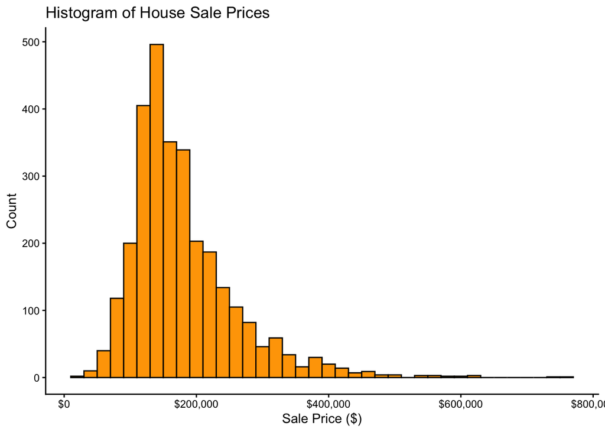

```r
#Histogram of SalePrice
ggplot(housing_dataset, aes(x = SalePrice)) +
  geom_histogram(binwidth = 20000, fill = "orange", color = "black") +
  labs(title = "Histogram of House Sale Prices",
       x = "Sale Price ($)", y = "Count") +
  scale_x_continuous(labels = dollar) +
  theme_classic()
```

## Data Preparation for Modelling

```r
#Prepare the dataset for modeling
#By imputing missing values with the variable's mean value
#Check for missing values
missing_values <- colSums(is.na(housing_dataset))
print(missing_values[missing_values > 0])
```

```
##   Lot.Frontage          Alley   Mas.Vnr.Area      Bsmt.Qual      Bsmt.Cond
##            490           2732             23             79             79
##  Bsmt.Exposure BsmtFin.Type.1   BsmtFin.SF.1 BsmtFin.Type.2   BsmtFin.SF.2
##             79             79              1             79              1
##    Bsmt.Unf.SF  Total.Bsmt.SF Bsmt.Full.Bath Bsmt.Half.Bath   Fireplace.Qu
##              1              1              2              2           1422
##    Garage.Type  Garage.Yr.Blt  Garage.Finish    Garage.Cars    Garage.Area
##            157            159            157              1              1
##    Garage.Qual    Garage.Cond        Pool.QC          Fence   Misc.Feature
##            158            158           2917           2358           2824
```

```r
#Create a copy of the dataset
clean_housing_dataset <- housing_dataset
#List of numeric variables names
numeric_variables <- names(clean_housing_dataset)[sapply(clean_housing_dataset, is.numeric)]

#Fill missing values in each numeric variable
for(column_name in numeric_variables) {
  #Check if there are any missing values
  if(any(is.na(clean_housing_dataset[[column_name]]))) {
    #Calculate the mean
    column_mean <- mean(clean_housing_dataset[[column_name]], na.rm = TRUE)
    #Replace missing values with the mean
    clean_housing_dataset[[column_name]][is.na(clean_housing_dataset[[column_name]])] <- column_mean
  }
}
```

This approach ensures the dataset is complete and suitable for modeling, without removing observations or introducing bias from excluding data. After imputation, all numeric variables contain no missing values, enabling reliable regression analysis.

## Correlation matrix of Numeric Variables

A correlation matrix was created using the cor() function for selected numeric variables in the Ames Housing dataset to examine the relationships between quantitative features, including sale price and size-related measurements like Lot.Frontage, Gr.Liv.Area, Garage.Area, and others.

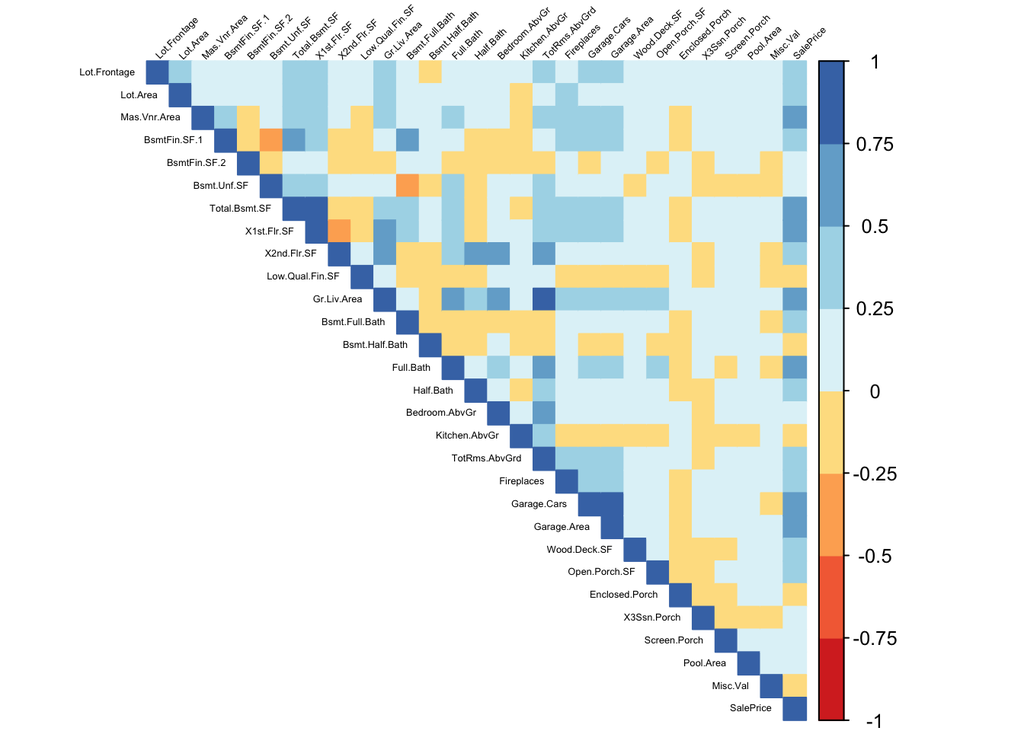

```r
#Correlation matrix of the numeric values
#Select only quantitative/numeric variables
quantitative_vars <- c("Lot.Frontage", "Lot.Area", "Mas.Vnr.Area",
                       "BsmtFin.SF.1", "BsmtFin.SF.2", "Bsmt.Unf.SF", "Total.Bsmt.SF",
                       "X1st.Flr.SF", "X2nd.Flr.SF", "Low.Qual.Fin.SF", "Gr.Liv.Area",
                       "Bsmt.Full.Bath", "Bsmt.Half.Bath", "Full.Bath", "Half.Bath",
                       "Bedroom.AbvGr", "Kitchen.AbvGr", "TotRms.AbvGrd", "Fireplaces",
                       "Garage.Cars", "Garage.Area", "Wood.Deck.SF", "Open.Porch.SF",
                       "Enclosed.Porch", "X3Ssn.Porch", "Screen.Porch", "Pool.Area",
                       "Misc.Val", "SalePrice")

numeric_values <- clean_housing_dataset[, names(clean_housing_dataset) %in% quantitative_vars]

#Compute correlation matrix
cors <- cor(numeric_values, use = "pairwise")

#Create correlation metix plot
corrplot(cors, method = "color", type = "upper",
         col = brewer.pal(n=8, name='RdYlBu'),
         tl.cex = 0.4, tl.col = "black",
         tl.srt = 45,number.cex = 0.5)
```

Positive correlations are shown in shades of blue, with darker blue indicating stronger positive relationships (values closer to +1). Negative correlations appear in shades of red/orange, with darker reds indicating stronger negative relationships (values closer to -1). Colors near white/yellow indicate weak or no correlation (values near 0).

Features like above-ground living area (Gr.Liv.Area) correlate strongly and positively with sale price, so expansive homes usually command higher market values. Likewise, basement measurements such as total basement square footage (Total.Bsmt.SF) also correlate positively with sale price, which suggests that finished basement space adds to a home’s value. On the flip side, some features like pool area or miscellaneous value show hardly any correlation with sale price or other variables. High correlations between predictors (for example, TotRms.AbvGrd and Gr.Liv.Area, as larger houses naturally have more rooms) warn about possible multicollinearity, which should be considered when selecting variables for regression models.

The plot helps identify important predictors for modeling and highlights potential multicollinearity among variables, guiding better feature selection for regression analysis.

## Scatter Plots of Continous Variable vs SalePrice

I created three scatter plots to examine how sale price relates to different continuous variables in the Ames Housing dataset:

```r
#select only continuous variables
continuous_vars <- clean_housing_dataset[, c("SalePrice","Gr.Liv.Area","Garage.Area",
  "Total.Bsmt.SF","Mas.Vnr.Area","BsmtFin.SF.1","Wood.Deck.SF","Open.Porch.SF",
  "X2nd.Flr.SF","Bsmt.Unf.SF","Enclosed.Porch","Screen.Porch","Low.Qual.Fin.SF",
  "X3Ssn.Porch","Misc.Val","BsmtFin.SF.2")]

cors_continous_variables <- cor(continuous_vars, use = "pairwise")

#Show correlation with sales price for continous variables only
saleprice_cors <- cors_continous_variables[, "SalePrice"]
saleprice_cors_continous <- sort(abs(saleprice_cors), decreasing = TRUE)
print(saleprice_cors_continous)
```

```
##       SalePrice     Gr.Liv.Area     Garage.Area   Total.Bsmt.SF    Mas.Vnr.Area
##     1.000000000     0.706779921     0.640385461     0.632105117     0.505784081
##    BsmtFin.SF.1    Wood.Deck.SF   Open.Porch.SF     X2nd.Flr.SF     Bsmt.Unf.SF
##     0.432794357     0.327143174     0.312950506     0.269373357     0.182804552
##  Enclosed.Porch    Screen.Porch Low.Qual.Fin.SF     X3Ssn.Porch        Misc.Val
##     0.128787442     0.112151214     0.037659765     0.032224649     0.015691463
##    BsmtFin.SF.2
##     0.005889764
```

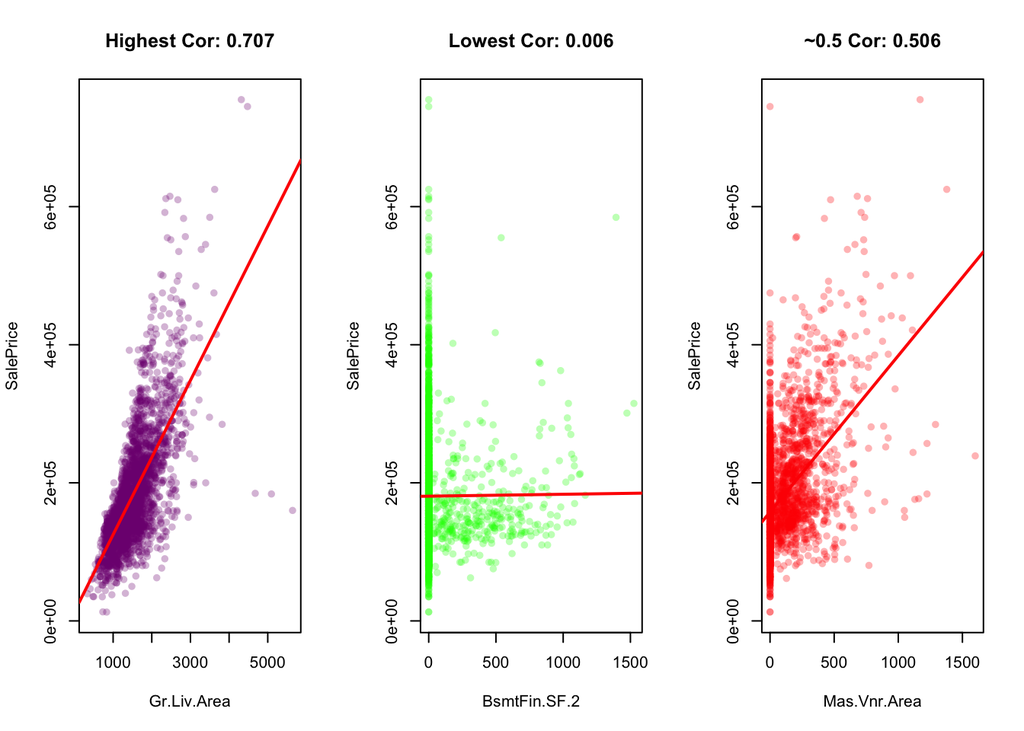

```r
#Find variables with highest, lowest, and ~0.5 correlation with SalePrice
#Remove SalesPrice itself
cors_with_price <- saleprice_cors[names(saleprice_cors) != "SalePrice"]

#Highest correlation
highest_var <- names(which.max(abs(cors_with_price)))
highest_cor <- cors_with_price[highest_var]

#Lowest correlation
lowest_var <- names(which.min(abs(cors_with_price)))
lowest_cor <- cors_with_price[lowest_var]

#Closest to 0.5
closest_05_var <- names(which.min(abs(abs(cors_with_price) - 0.5)))
closest_05_cor <- cors_with_price[closest_05_var]

#Create scatter plots
par(mfrow = c(1, 3))

#Scatter plot for the Gr.Liv.Area vs SalePrice
plot(clean_housing_dataset[[highest_var]], clean_housing_dataset$SalePrice,
     xlab = highest_var, ylab = "SalePrice",
     main = paste("Highest Cor:", round(highest_cor, 3)),
     pch = 16, col = rgb(0.5, 0, 0.5, 0.3))
abline(lm(SalePrice ~ clean_housing_dataset[[highest_var]], data = clean_housing_dataset),
       col = "red", lwd = 2)

#Scatter plot for the BsmtFin.SF.2 vs SalePrice
plot(clean_housing_dataset[[lowest_var]], clean_housing_dataset$SalePrice,
     xlab = lowest_var, ylab = "SalePrice",
     main = paste("Lowest Cor:", round(lowest_cor, 3)),
     pch = 16, col = rgb(0, 1, 0, 0.3))
abline(lm(SalePrice ~ clean_housing_dataset[[lowest_var]], data = clean_housing_dataset),
       col = "red", lwd = 2)

#Scatter plot for the Mas.Vnr.Area vs SalePrice
plot(clean_housing_dataset[[closest_05_var]], clean_housing_dataset$SalePrice,
     xlab = closest_05_var, ylab = "SalePrice",
     main = paste("~0.5 Cor:", round(closest_05_cor, 3)),
     pch = 16, col = rgb(1, 0, 0, 0.3))
abline(lm(SalePrice ~ clean_housing_dataset[[closest_05_var]], data = clean_housing_dataset),
       col = "red", lwd = 2)
```

```r
par(mfrow = c(1, 1))
```

Lowest Correlation: BsmtFin.SF.2 (r = 0.006) When looking at the second type of finished basement area, the scatter plot shows practically no connection to sale price. The points are all over the place with no discernible pattern, and the regression line is basically horizontal, which matches up with the correlation being almost zero.

Moderate Correlation: Mas.Vnr.Area (r = 0.506) The plot comparing masonry veneer area to sale price shows a moderate positive correlation. There’s a general upward trend indicating that more veneer area typically means higher prices, but the points are more spread out than with above-ground living area. This tells me that while veneer area matters, other factors are also playing a role in determining sale price.

These plots demonstrate how correlation values correspond to visual patterns: strong correlations align with clear linear trends; weak correlations appear as random scatter, and moderate correlations show a trend with notable variability. This visual insight helps prioritize variables for regression modeling based on their explanatory power.

## Multi Linear Regression Model using Continuous Variables

A multiple linear regression model was built to predict residential sale prices, utilizing four continuous variables with substantial connections to price: living area above ground, garage area, basement area, and masonry veneer area.

```r
#Fit multiple liner regression model
#Use 4 continous variables based on high correlations with SalesPrice
model1 <- lm(SalePrice ~ Gr.Liv.Area + Garage.Area + Total.Bsmt.SF + Mas.Vnr.Area,
             data = clean_housing_dataset)

#View model summary
summary(model1)
```

```
##
## Call:
## lm(formula = SalePrice ~ Gr.Liv.Area + Garage.Area + Total.Bsmt.SF +
##     Mas.Vnr.Area, data = clean_housing_dataset)
##
## Residuals:
##     Min      1Q  Median      3Q     Max
## -668445  -20180     418   19680  281581
##
## Coefficients:
##                 Estimate Std. Error t value Pr(>|t|)
## (Intercept)   -18798.744   2911.455  -6.457 1.25e-10 ***
## Gr.Liv.Area       63.798      1.968  32.421  < 2e-16 ***
## Garage.Area       97.171      4.676  20.782  < 2e-16 ***
## Total.Bsmt.SF     49.106      2.253  21.797  < 2e-16 ***
## Mas.Vnr.Area      62.148      5.240  11.859  < 2e-16 ***
## ---
## Signif. codes:  0 '***' 0.001 '**' 0.01 '*' 0.05 '.' 0.1 ' ' 1
##
## Residual standard error: 44210 on 2925 degrees of freedom
## Multiple R-squared:  0.6942, Adjusted R-squared:  0.6938
## F-statistic:  1660 on 4 and 2925 DF,  p-value: < 2.2e-16
```

The model accounts for about 69.4% of the variation in sale prices (adjusted R2 = 0.694), with all predictors showing positive relationships and being statistically significant. For example, larger living areas are associated with higher sale prices. The residual standard error of roughly $44,210 indicates a moderate level of uncertainty in the predictions. Overall, the model captures key size-related factors affecting home prices, though some variation remains unexplained, suggesting that other factors also play a role.

The resulting model equation is: Predicted SalePrice = −18,798.74 + 63.80(Gr.Liv.Area) + 97.17(Garage.Area) + 49.11(Total.Bsmt.SF) + 62.15(Mas.Vnr.Area)

Each variable represents area measured in square ft. The intercept (−$18,798.74) serves as a baseline with no real-world meaning. With all else fixed, each square foot adds: $63.80 (living area), $97.17 (garage), $49.11 (basement), or $62.15 (masonry veneer). Simply put: larger, better- appointed homes fetch higher prices.

As noted, all predictors are statistically significant and positively related to sale price, and the model explains roughly 69.4% of the variation in home sale prices. This highlights the strong effect of size- related features while acknowledging that other factors also influence housing values. When I use the plot() function, it creates four standard diagnostic plots that help me check whether the linear regression model meets its key assumptions.

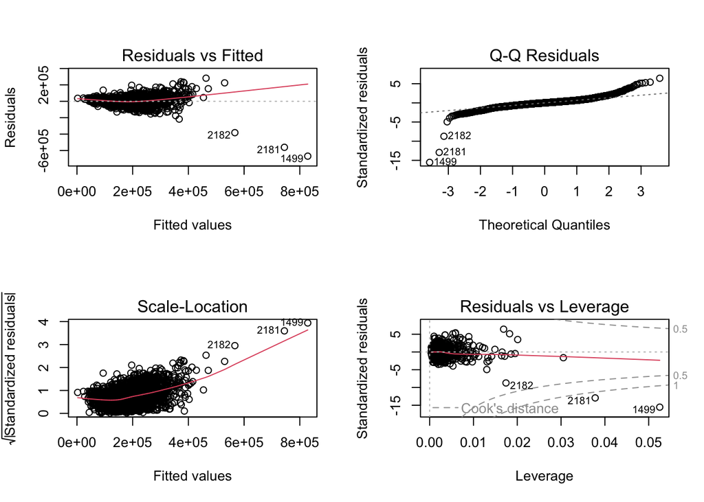

```r
#Plot regression model
#Review diagnostics plots
#Residual vs Fitted - Linearity
#Normal Q-Q plot - Normality
#Scale - Location - homoscedasticity (constant variance)
#Residuals vs Leverage (Unusual observations)
par(mfrow = c(2,2))
plot(model1)
```

Residuals vs Fitted (Linearity): Figure examines the linearity assumption by displaying how residuals behave relative to fitted values. A well-specified linear model would show random dispersion around zero. Here, the residuals largely concentrate around the zero line, suggesting the linear framework captures the relationship reasonably well. That said, I notice a slight upward trend and the residuals spread out more when the fitted values get higher. This hints at some mild nonlinearity and heteroscedasticity - basically, the model isn’t as accurate when predicting really expensive homes. The labeled points (e.g., 2182, 2181, and 1499) correspond to properties with unusually large residuals, showing that their sale prices are not well predicted by the model. These homes, likely at the high end of the price range, highlight where the model is less accurate.

Scale–Location Plot (Homoscedasticity): This plot checks if the residuals have a consistent spread across all predicted sale prices. Ideally, the points should form a flat line with equal scatter. In my model, the spread of residuals gets a bit wider for higher-priced homes, which means the model’s prediction errors are larger for expensive properties. The points labeled 2182, 2181, and 1499 are individual homes with unusually large errors, showing where the model doesn’t predict as well.

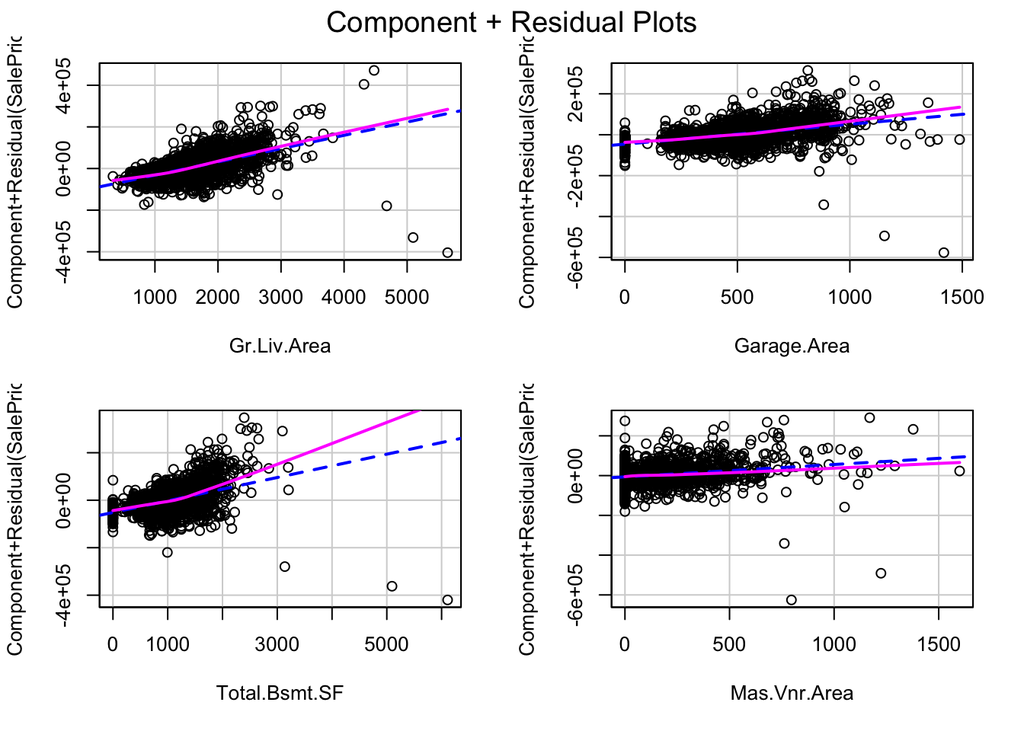

```r
#Component + Residuals linearity
crPlots(model = model1)
```

In the Component + Residuals plots, each predictor shows how it relates to the residuals after accounting for other variables. The pink line shows a smooth trend, and the blue line represents the linear relationship. For most variables, the pink line follows the blue line closely, meaning the linear assumption is mostly fine. For Total.Bsmt.SF, the pink line curves up slightly at higher values, which suggests a small departure from linearity basements that are very large have a slightly stronger effect on sale price than the straight-line model predicts. Overall, the model works well, but there’s little nonlinearity for some predictors.

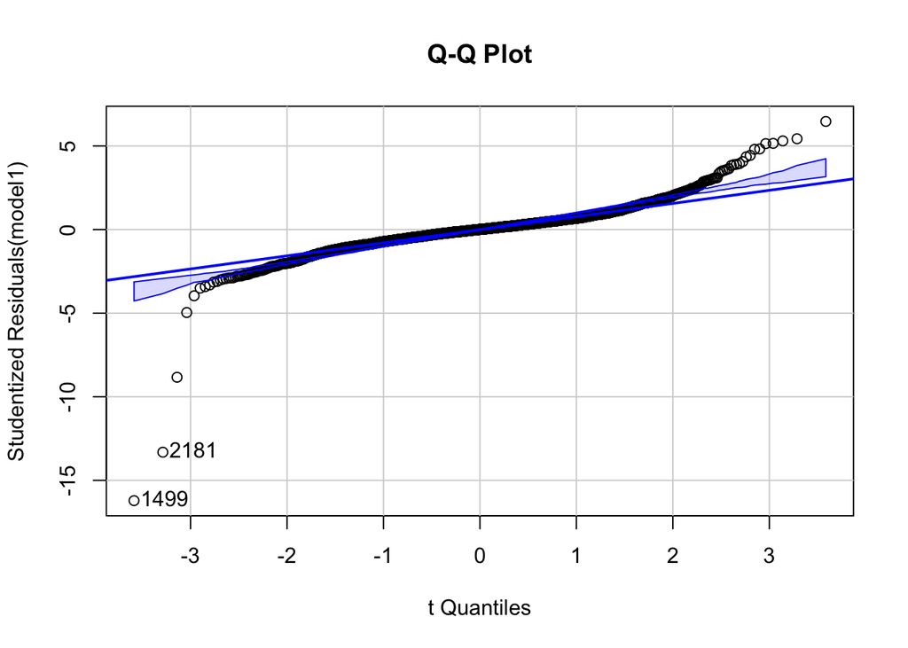

```
## [1] 1499 2181
```

```r
#Q-Q plot normality using car library
qqPlot(model1, labels = row.names(clean_housing_dataset), simulate = TRUE, main = 'Q-Q Plot')
```

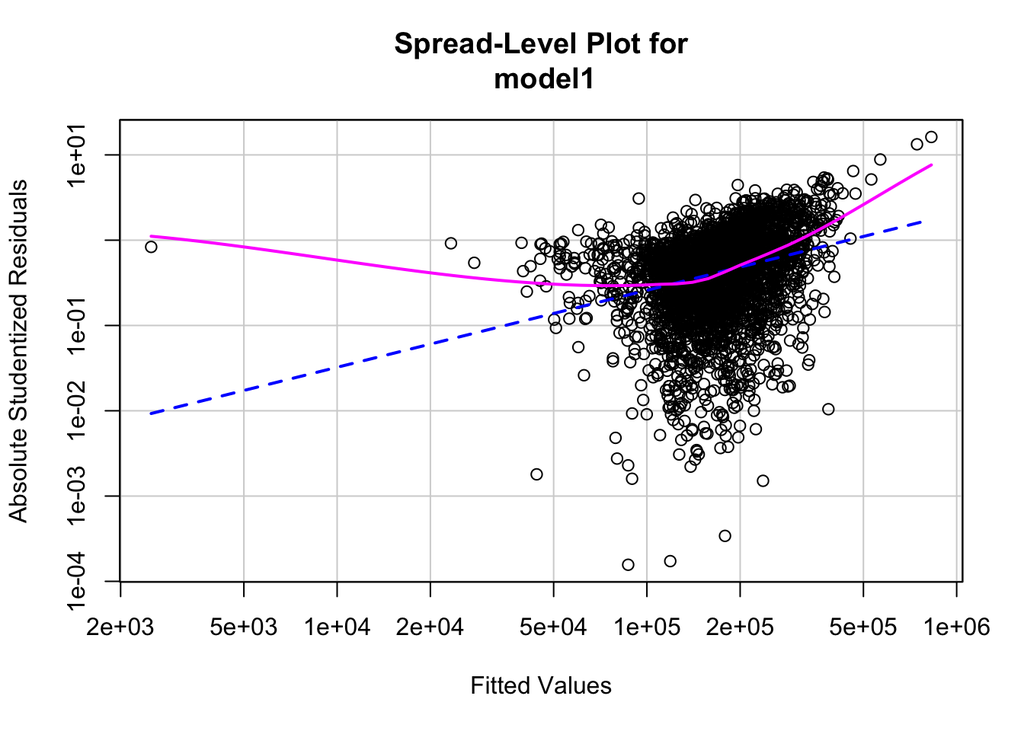

```
##
## Suggested power transformation:  0.09710237
```

```r
#Spread-Level plot for fit - homoscedasticity
spreadLevelPlot(model1)
```

In a nutshell, diagnostic plots show that the regression model works well and mostly satisfies the assumptions of linear regression. However, there is some mild heteroscedasticity, a little deviation from normality in extreme values, and a few influential data points. These observations suggest that using transformations (like taking the log of SalePrice) or including more variables could help improve the model’s accuracy.

## Check Model for Multicollinearity

To evaluate multicollinearity in the regression model, Variance Inflation Factors (VIFs) were computed for each predictor

```r
#Check model for multicollinearity
vif(model1)
```

```
##   Gr.Liv.Area   Garage.Area Total.Bsmt.SF  Mas.Vnr.Area
##      1.482947      1.514685      1.476239      1.309974
```

The VIF values I calculated are 1.48 for above-ground living area, 1.51 for garage area, 1.48 for total basement square footage, and 1.31 for masonry veneer area. These numbers are all way below the usual warning signs - typically a VIF above 5 suggests moderate multicollinearity issues, and above 10 means serious problems. Since mine are so low, there’s no multicollinearity problem to worry about in this model. This means my predictor variables aren’t too closely related to each other, so the coefficients I’m getting are solid and trustworthy. If I had found multicollinearity, I would’ve needed to either drop some variables or combine the ones that were too similar.

## Identifying Outliers

When examining the model for outliers, certain homes are identified as having unusually large residuals, meaning their actual sale prices differ greatly from the model’s predictions. The most extreme cases are homes 1499, 2181, and 2182, which have large negative residuals, indicating that the model overestimates their prices. Other outliers, such as 1761, 45, and 1064, show large positive or negative residuals. The extremely small p-values suggest that these differences are statistically significant. These unusual or extreme properties can have a strong influence on the model and identifying them helps determine whether further investigation or model adjustments are needed to improve predictions.

```r
#Check model for outliers
#Outliers
outlierTest(model = model1)
```

```
##        rstudent unadjusted p-value Bonferroni p
## 1499 -16.214297         1.1032e-56   3.2323e-53
## 2181 -13.316165         2.5448e-39   7.4563e-36
## 2182  -8.834041         1.7062e-18   4.9992e-15
## 1761   6.468549         1.1557e-10   3.3863e-07
## 45     5.432820         6.0027e-08   1.7588e-04
## 1064   5.306022         1.2042e-07   3.5282e-04
## 1768   5.156094         2.6896e-07   7.8806e-04
## 433    5.140598         2.9190e-07   8.5527e-04
## 1183  -4.961850         7.3822e-07   2.1630e-03
## 2333   4.824207         1.4776e-06   4.3295e-03
```

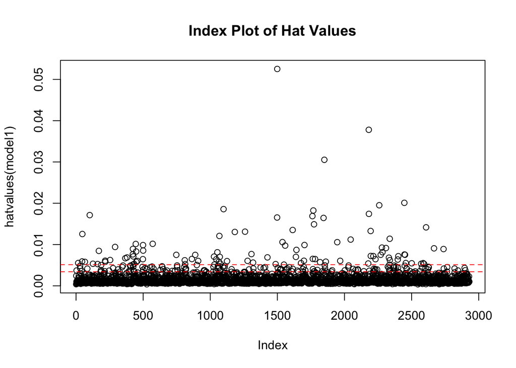

```
## integer(0)
```

```r
#High leverage observation
hat.plot <- function(model1) {
  p <- length(coefficients(model1))
  n <- length(fitted(model1))
  plot(hatvalues(model1), main = "Index Plot of Hat Values")
  abline(h = c(2,3)*p/n, col = "red", lty = 2)
  identify(1:n, hatvalues(model1), names(hatvalues(model1)))
}
hat.plot(model1)
```

The Cook’s distance plot shows which homes might have a strong influence on the model. Points above the red dashed line are considered potentially influential. In my plot, homes 1499, 2181, and 2182 stand out. Home 1499 is both high-leverage and influential, meaning it could strongly affect the model’s results. Homes 2181 and 2182 are also influential. These points don’t necessarily mean the model is wrong, but they are unusual cases that should be looked at more closely to understand why they differ from the rest of the homes.

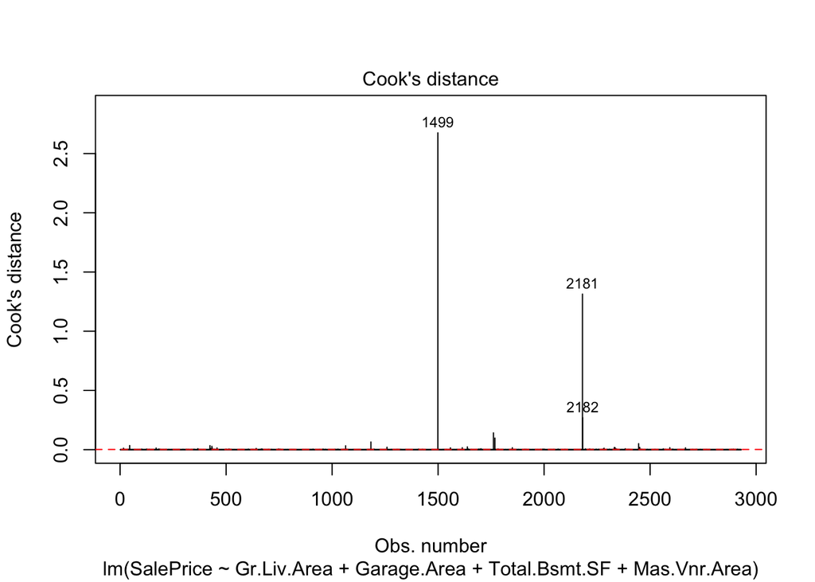

```r
#Influential Observations
cutoff <- 4/(nrow(clean_housing_dataset) - length(model1$coefficients - 2))
plot(model1, which = 4, cook.levels = cutoff)
abline(h = cutoff, lty = 2, col = "red")
```

## Transformation

The use of powerTransform function shows how we can change SalePrice to make the model work better. It estimated a power of about 0 (0.0076 rounded to 0), which means a log transformation would be ideal. This makes sense because the original SalePrice is skewed and not perfectly normal. I used a square root transformation instead, which is a smaller change but still helpful. The tests show that using no transformation is not good (very small p-value), while a log transformation would work well (large p-value).

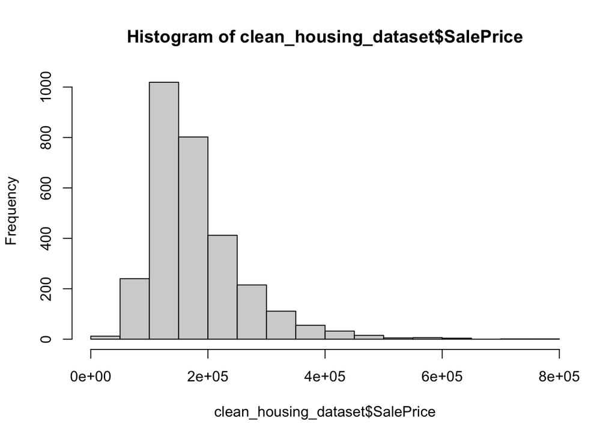

```r
#View distribution of response variable
hist(clean_housing_dataset$SalePrice)
```

```r
#Use power transform function to determine transformation
summary(powerTransform(clean_housing_dataset$SalePrice))
```

```
## bcPower Transformation to Normality
##                                 Est Power Rounded Pwr Wald Lwr Bnd Wald Upr Bnd
## clean_housing_dataset$SalePrice    0.0076           0      -0.0501       0.0654
##
## Likelihood ratio test that transformation parameter is equal to 0
##  (log transformation)
##                              LRT df    pval
## LR test, lambda = (0) 0.06741106  1 0.79514
##
## Likelihood ratio test that no transformation is needed
##                            LRT df       pval
## LR test, lambda = (1) 966.3636  1 < 2.22e-16
```

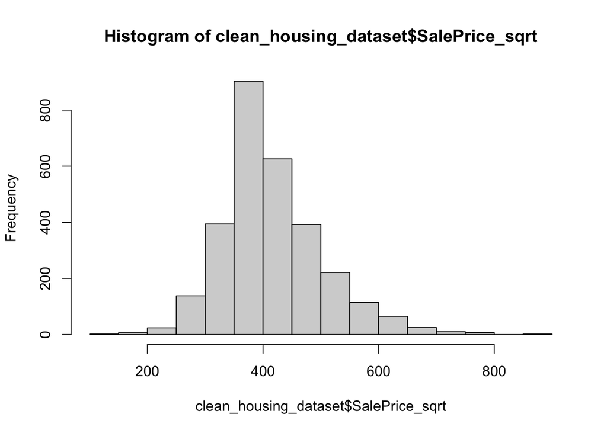

```r
#Apply the transformation and review the result
clean_housing_dataset$SalePrice_sqrt <- sqrt(clean_housing_dataset$SalePrice)
hist(clean_housing_dataset$SalePrice_sqrt)
```

In simple terms, transforming SalePrice helps make the residuals more normally distributed and reduces issues like uneven spread of errors. Applying the square root transformation improves the model, although a log transformation might offer slightly better results. After taking the square root, the model fits a little better: the adjusted R2 rises to 0.705, meaning it now explains about 70.5% of the variation in home prices. All four predictors remain highly significant, with larger living areas, garages, basements, and masonry veneer areas continuing to increase home prices. The residual standard error on the transformed scale is 47.1, indicating that predictions are somewhat more consistent. Overall, the transformation reduced large errors for expensive homes and made the model more reliable while preserving the key relationships.

```r
#model2 square root transformation
model2 <- lm(SalePrice_sqrt ~ Gr.Liv.Area + Garage.Area + Total.Bsmt.SF + Mas.Vnr.Area,
                data = clean_housing_dataset)
summary(model2)
```

```
##
## Call:
## lm(formula = SalePrice_sqrt ~ Gr.Liv.Area + Garage.Area + Total.Bsmt.SF +
##     Mas.Vnr.Area, data = clean_housing_dataset)
##
## Residuals:
##     Min      1Q  Median      3Q     Max
## -725.88  -21.48    3.05   25.49  189.75
##
## Coefficients:
##                Estimate Std. Error t value Pr(>|t|)
## (Intercept)   1.940e+02  3.102e+00  62.550   <2e-16 ***
## Gr.Liv.Area   7.025e-02  2.096e-03  33.513   <2e-16 ***
## Garage.Area   1.158e-01  4.981e-03  23.239   <2e-16 ***
## Total.Bsmt.SF 5.428e-02  2.400e-03  22.615   <2e-16 ***
## Mas.Vnr.Area  4.989e-02  5.583e-03   8.936   <2e-16 ***
## ---
## Signif. codes:  0 '***' 0.001 '**' 0.01 '*' 0.05 '.' 0.1 ' ' 1
##
## Residual standard error: 47.1 on 2925 degrees of freedom
## Multiple R-squared:  0.7056, Adjusted R-squared:  0.7052
## F-statistic:  1753 on 4 and 2925 DF,  p-value: < 2.2e-16
```

## Use All Subset Regression to Identify the Best Model

The all subsets regression plot displays all possible combinations of the four predictor variables along with their adjusted R2 values. The black shading indicates the models that achieve the highest adjusted R2 for each number of predictors.

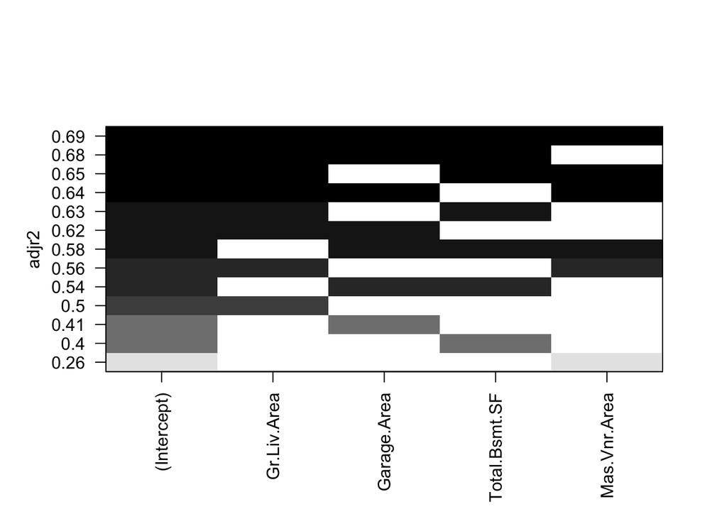

```r
#Best Subset
leaps <- regsubsets(SalePrice ~ Gr.Liv.Area + Garage.Area + Total.Bsmt.SF + Mas.Vnr.Area,
                     data = clean_housing_dataset, nbest = 4)

plot(leaps, scale = "adjr2")
```

Based on the plot, the four-variable model incorporating Gr.Liv.Area, Garage.Area, Total.Bsmt.SF, and masonry veneer area demonstrates the strongest performance, achieving an adjusted R2 of approximately 0.69. This means it accounts for roughly 69% of the differences we see in sale prices. When I tested models with fewer variables, they had lower adjusted R2 values, so they weren’t as good at explaining price variations. This tells me the four-variable model is the winner since it gives the most accurate and complete picture of what drives home prices.

The model equation is: Predicted SalePrice = −18,798.74 + 63.80(Gr.Liv.Area) + 97.17(Garage.Area) + 49.11(Total.Bsmt.SF) + 62.15(Mas.Vnr.Area).

This shows that each of the four area-related variables has a positive effect on sale price, and including all of them gives the most reliable predictions.

```r
#Review Results
summary(leaps)
```

```
## Subset selection object
## Call: regsubsets.formula(SalePrice ~ Gr.Liv.Area + Garage.Area + Total.Bsmt.SF +
##     Mas.Vnr.Area, data = clean_housing_dataset, nbest = 4)
## 4 Variables  (and intercept)
##               Forced in Forced out
## Gr.Liv.Area       FALSE      FALSE
## Garage.Area       FALSE      FALSE
## Total.Bsmt.SF     FALSE      FALSE
## Mas.Vnr.Area      FALSE      FALSE
## 4 subsets of each size up to 4
## Selection Algorithm: exhaustive
##          Gr.Liv.Area Garage.Area Total.Bsmt.SF Mas.Vnr.Area
## 1  ( 1 ) "*"         " "         " "           " "
## 1  ( 2 ) " "         "*"         " "           " "
## 1  ( 3 ) " "         " "         "*"           " "
## 1  ( 4 ) " "         " "         " "           "*"
## 2  ( 1 ) "*"         " "         "*"           " "
## 2  ( 2 ) "*"         "*"         " "           " "
## 2  ( 3 ) "*"         " "         " "           "*"
## 2  ( 4 ) " "         "*"         "*"           " "
## 3  ( 1 ) "*"         "*"         "*"           " "
## 3  ( 2 ) "*"         " "         "*"           "*"
## 3  ( 3 ) "*"         "*"         " "           "*"
## 3  ( 4 ) " "         "*"         "*"           "*"
## 4  ( 1 ) "*"         "*"         "*"           "*"
```

## Compare the Preferred Model

The two models use an identical set of four predictor variables: living space above ground, garage square footage, total basement area, and masonry veneer coverage. Where they differ is in their target outcome what each model aims to forecast. The first model predicts the actual sale price as- is, while the second model predicts the square root of the sale price. I used the square root transformation in the second model to make the data less skewed and get a better-fitting model overall.

• Adjusted R-squared: model1 explains about 69.4% of the variation in SalePrice, while model2 explains slightly more, 70.5%, showing a small improvement in overall fit.

• Residuals: model1 has a much larger residual standard error (about 44,210), reflecting the original scale of sale prices, and errors increase with high-priced homes. model2’s residual standard error is 47.1 on the transformed scale, showing that prediction errors are more consistent across the dataset.

• Significance of predictors: Both models show all predictors are highly significant, and the direction of the effect (positive relationship with sale price) stays the same.

model2 is slightly better because the square root transformation reduces skewness, stabilizes variance (reduces heteroscedasticity), and makes the residuals closer to normal. This improves the reliability of predictions, especially for higher-priced homes, even though the set of predictors hasn’t changed. model1 works fine, but model2 provides a more robust and statistically sound fit.